# Reproducible Research: Peer Assessment 1

## Loading and preprocessing the data

#### 1. Load the data (i.e. read.csv())

```r
MyActivity <- read.csv("activity.csv")
```

#### 2. Process/transform the data (if necessary) into a format suitable for your analysis

```r
head(MyActivity)
```

```
##   steps       date interval
## 1    NA 2012-10-01        0
## 2    NA 2012-10-01        5
## 3    NA 2012-10-01       10
## 4    NA 2012-10-01       15
## 5    NA 2012-10-01       20
## 6    NA 2012-10-01       25
```

```r
str(MyActivity)
```

```
## 'data.frame':    17568 obs. of  3 variables:
##  $ steps   : int  NA NA NA NA NA NA NA NA NA NA ...
##  $ date    : Factor w/ 61 levels "2012-10-01","2012-10-02",..: 1 1 1 1 1 1 1 1 1 1 ...
##  $ interval: int  0 5 10 15 20 25 30 35 40 45 ...
```

## What is mean total number of steps taken per day?

#### 1. Calculate the total number of steps taken per day

```r
Tot_Steps_day <- tapply(MyActivity$steps, MyActivity$date, sum, na.rm = TRUE)
```

- Total number of steps taken per day: 0, 126, 11352, 12116, 13294, 15420, 11015, 0, 12811, 9900, 10304, 17382, 12426, 15098, 10139, 15084, 13452, 10056, 11829, 10395, 8821, 13460, 8918, 8355, 2492, 6778, 10119, 11458, 5018, 9819, 15414, 0, 10600, 10571, 0, 10439, 8334, 12883, 3219, 0, 0, 12608, 10765, 7336, 0, 41, 5441, 14339, 15110, 8841, 4472, 12787, 20427, 21194, 14478, 11834, 11162, 13646, 10183, 7047, 0

#### 2. Make a histogram of the total number of steps taken each day

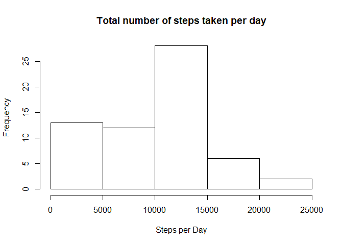

```r
hist(Tot_Steps_day,
      xlab = "Steps per Day",
      main = "Total number of steps taken per day")
```

#### 3. Calculate and report the mean and median total number of steps taken per day

```r
mean_Steps   <- mean(Tot_Steps_day)
median_Steps <- median(Tot_Steps_day)
```

- Mean: 9354.2295082
- Median: 10395

## What is the average daily activity pattern?

#### 1. Make a time series plot (i.e. type=“l”) of the 5-minute interval (x-axis) and the average number of steps taken, averaged across all days (y-axis)

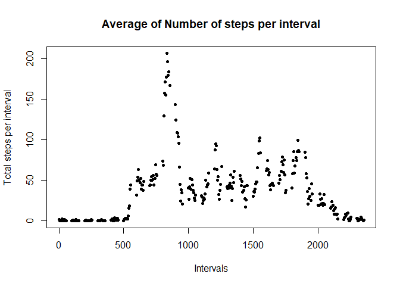

```r
Ave_Steps_Interval <- tapply(MyActivity$steps, MyActivity$interval, mean, na.rm = TRUE)
plot(unique(MyActivity$interval),Ave_Steps_Interval,
      xlab = "Intervals",
      ylab = "Total steps per interval",
      main = "Average of Number of steps per interval",
      pch = 20)
```

#### 2. Which 5-minute interval, on average across all the days in the dataset, contains the maximum number of steps?

```r
max_Steps <- max(Ave_Steps_Interval)
max_interval <- unique(MyActivity$interval)[which(Ave_Steps_Interval == max(Ave_Steps_Interval))]
```

- Interval with maximum number of steps: 835

## Imputing missing values

#### 1. Calculate and report the total number of missing values in the dataset (i.e. the total number of rows with NAs)

```r
TotNas <- sum(is.na(MyActivity))
```

- Number of missing values: 2304

#### 2. Devise a strategy for filling in all of the missing values in the dataset. The strategy does not need to be sophisticated. For example, you could use the mean/median for that day, or the mean for that 5-minute interval, etc.

#### 3. Create a new dataset that is equal to the original dataset but with the missing data filled in.

```r
UpdatedMyActivity <- MyActivity


MeanSteps <- tapply(MyActivity$steps, MyActivity$interval, mean, na.rm = TRUE)
MyActivity_NAs    <- MyActivity[ is.na(MyActivity$steps),]
MyActivity_nonNAs <- MyActivity[!is.na(MyActivity$steps),]
MyActivity_NAs$steps <- as.factor(MyActivity_NAs$interval)
levels(MyActivity_NAs$steps) <- MeanSteps
levels(MyActivity_NAs$steps) <- as.numeric(levels(MyActivity_NAs$steps))
MyActivity_NAs$steps <- as.integer(as.vector(MyActivity_NAs$steps))
UpdatedMyActivity <- rbind(MyActivity_NAs, MyActivity_nonNAs)
```

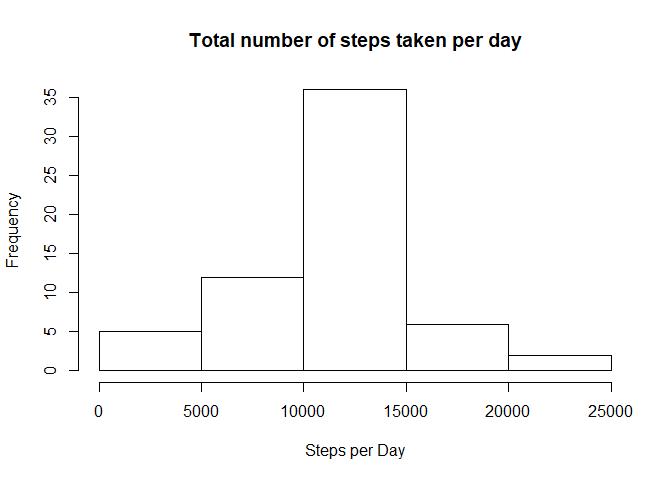

```r
Tot_Steps_day2 <- tapply(UpdatedMyActivity$steps, UpdatedMyActivity$date, sum)
hist(Tot_Steps_day2,
      xlab = "Steps per Day",
      main = "Total number of steps taken per day")
```

```r
mean_Steps2   <- mean(Tot_Steps_day2)
median_Steps2 <- median(Tot_Steps_day2)
```

## Are there differences in activity patterns between weekdays and weekends?

#### 1. Create a new factor variable in the dataset with two levels - “weekday” and “weekend” indicating whether a given date is a weekday or weekend day.

```r
UpdatedMyActivity$Weektype <- ifelse(weekdays(as.Date(UpdatedMyActivity$date)) == "Saturday" | weekdays(as.Date(UpdatedMyActivity$date)) == "Sunday", "weekend", "weekday" )
```

#### 2. Make a panel plot containing a time series plot (i.e. type=“l”) of the 5-minute interval (x-axis) and the average number of steps taken, averaged across all weekday days or weekend days (y-axis). See the README file in the GitHub repository to see an example of what this plot should look like using simulated data.

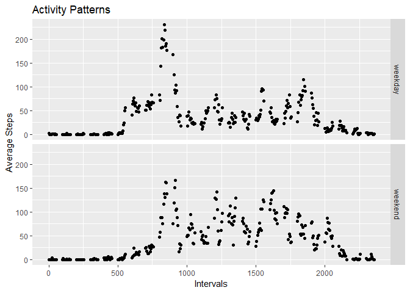

```r
StepsIntervalWeekday <- aggregate(steps ~ interval + Weektype, data = UpdatedMyActivity, FUN = mean)
names(StepsIntervalWeekday) <- c("interval", "Weektype", "meansteps")

library(ggplot2)
pp <- ggplot(StepsIntervalWeekday, aes(interval, meansteps))
pp + geom_point() + facet_grid(Weektype~.) + labs(x = "Intervals", y = "Average Steps", title = "Activity Patterns")
```